# Projet - Leg Resistance Analysis

# Introduction

Ce travail comporte une étude statistique des données issues de l’article suivant : *S Maeda, T Otsuki, M Iemitsu, M Kamioka, J Sugawara, S Kuno, R Ajisaka, and H Tanaka, Effects of leg resistance training on arterial function in older men, Br J Sports Med. 2006 Oct ; 40(10) : 867869*

<sub>Projet réalisé dans le cadre d’un travail universitaire (données fournies par l’enseignant)</sub>

**Objectif de l’étude :**

L’objectif de cette étude est de déterminer l’effet de la musculation (Leg resistance) sur la rigidité artérielle et les fonctions endothéliales chez des personnes âgées.

**Hypothèse de recherche :**

Ce type d’exercices améliorerait les fonctions endothéliales sans pour autant augmenter la rigidité artérielle.

**Méthode :**

Étude portée sur onze hommes en bonne santé, âgés de 60 à 67 ans pendant 12 semaines. Les exercices effectués consistait en une succession de flexion/extension du genou (trois répétitions par jour, 2 fois par semaine).

## Chargement du jeu de données et packages

Nous commençons par charger les différents packages dont nous aurons besoin pour notre étude.

```r
library(knitr)
library(kableExtra)
library(car)
```

Puis, nous chargeons nos données dans un jeu de données appelé **sport**.

```r
sport = read.table("sport.csv", header=T,sep=',',row.names = 1)
```

```r
kable(head(sport,4),caption="En-tête de nos données")
```

En-tête de nos données

| height | body.weight.before | bmi.before | heart.rate.before | blood.pressure.sys.before | blood.pressure.dia.before | tot.chol.before | hdl.chol.before | ldl.chol.before | serum.insulin.before | plasma.glucose.before | max.strength.before | aortic.pulse.wave.before | plasma.nitrite.before | plasma.endothelin.before | body.weight.after | bmi.after | heart.rate.after | blood.pressure.sys.after | blood.pressure.dia.after | tot.chol.after | hdl.chol.after | ldl.chol.after | serum.insulin.after | plasma.glucose.after | max.strength.after | aortic.pulse.wave.after | plasma.nitrite.after | plasma.endothelin.after |
| --- | --- | --- | --- | --- | --- | --- | --- | --- | --- | --- | --- | --- | --- | --- | --- | --- | --- | --- | --- | --- | --- | --- | --- | --- | --- | --- | --- | --- |
| 161.06 | 78.87 | 30.40 | 60 | 122.07 | 67.22 | 5.97 | 1.79 | 3.84 | 8.66 | 5.30 | 101.50 | 941.04 | 15.73 | 3.73 | 43.85 | 16.90 | 54 | 112.88 | 78.13 | 5.46 | 1.65 | 3.99 | 4.18 | 5.64 | 166.98 | 864.02 | 76.25 | 2.40 |
| 174.15 | 61.99 | 20.43 | 57 | 117.99 | 63.82 | 5.02 | 1.80 | 2.48 | 4.75 | 5.09 | 112.54 | 973.67 | 47.09 | 4.86 | 75.29 | 24.82 | 55 | 132.43 | 78.23 | 5.01 | 2.04 | 3.90 | 5.70 | 5.46 | 107.17 | 951.83 | 62.03 | 5.10 |
| 156.07 | 55.99 | 22.98 | 59 | 121.35 | 79.87 | 4.64 | 1.40 | 2.82 | 6.77 | 5.84 | 136.44 | 953.80 | 30.13 | 4.19 | 49.04 | 20.13 | 56 | 122.21 | 86.24 | 5.73 | 1.67 | 3.51 | 2.67 | 5.63 | 154.23 | 922.90 | 46.78 | 5.65 |
| 152.71 | 65.02 | 27.88 | 58 | 112.00 | 84.36 | 4.46 | 1.54 | 3.57 | 9.27 | 5.61 | 141.78 | 935.81 | 39.82 | 5.19 | 61.24 | 26.26 | 54 | 119.28 | 80.63 | 5.11 | 1.79 | 4.45 | 3.61 | 5.99 | 144.14 | 891.11 | 71.68 | 4.24 |

# Étude statistique

Afin de rester fidèle aux résultats de l’étude, nous exprimerons nos résultats sous la forme : moyenne(sem).

Étant donné l’objectif de cette étude nous mettrons en évidence trois variables :

- Aortic pulse wave velocity : directement lié à la rigidité artérielle
- Plasma nitrite/nitrate (Nox) level : lié au fonction endothéliale (vasodilatation)
- Plasma endothelin-1 level : lié au fonction endothéliale (vasoconstriction)

Dans un premier temps, nous définissons une fonction `SEM` calculant l’erreur type (SEM) :

```r
# Fonction afin de calculer le SEM :
SEM = function(x)
  sd(x)/sqrt(length(x))
```

Nous allons maintenant calculer la moyenne et le SEM pour chacune de nos variables en faisant la distinction **Avant/Après**.

```r
# Table 1 - Variables primaires

tab1 = array(0,c(3,2))

sport1 = sport[,c(13:15)]
sport2 = sport[,c(27:29)]

for (i in 1:3){
  moy = round(mean(sport1[,i]),2)
  sem = round(SEM(sport1[,i]),2)
  tab1[i,1] = paste(moy,"(",sem,")")
}

for (j in 1:3){
  moy = round(mean(sport2[,j]),2)
  sem = round(SEM(sport2[,j]),2)
  tab1[j,2] = paste(moy,"(",sem,")")
}

row.names(tab1) = c("Aortic pulse wave (cm/s)","Plasma nitrite (µmol/l)",
                    "Plasma endothelin (pg/ml")
colnames(tab1) = c("Avant","Après")

kable(tab1)
```

|  | Avant | Après |
| --- | --- | --- |
| Aortic pulse wave (cm/s) | 948.22 ( 15.55 ) | 919.9 ( 10.54 ) |
| Plasma nitrite (µmol/l) | 34.9 ( 4.19 ) | 55.99 ( 7.21 ) |
| Plasma endothelin (pg/ml | 4.58 ( 0.27 ) | 4.92 ( 0.3 ) |

```r
# Table 2
tab2 = array(0,c(12,2))

sport1 = sport[,1:12]
sport2 = sport[,16:26]

for (i in 1:12){
  moy = round(mean(sport1[,i]),2)
  sem = round(SEM(sport1[,i]),2)
  tab2[i,1] = paste(moy, "(",sem,")")
}

for (j in 2:length(sport2)+1){
  moy = round(mean(sport2[,(j-1)]),2)
  sem = round(SEM(sport2[,(j-1)]),2)
  tab2[j,2]= paste(moy, "(",sem,")")
}
tab2[1,2] = "-"
tab2[2,2] = paste(round(mean(sport2[,1]),2),"(",round(SEM(sport2[,1]),2),")")

row.names(tab2) = c("Height (cm)", "Body Weigth (kg)", "Body Mass Index (Kg/m^2)",
                    "Heart Rate (beats/min)", "Blood Pressure Systolic (mm Hg)",
                    "Blood Pressure Diastolic (mm Hg)","Total Cholesterol (mmol/L)",
                    "HDL-Cholesterol (mmol/L)", "LDL-Cholesterol (mmol/L)",
                    "Serum Insulin (μU/mL)", "Plasme Glucose (mmol/L)",
                    "Maximal Muscular Strength (N.m)")

colnames(tab2) = c("Avant","Après")
kable(tab2)
```

|  | Avant | Après |
| --- | --- | --- |
| Height (cm) | 165.02 ( 3.23 ) | - |
| Body Weigth (kg) | 62.14 ( 2.2 ) | 55.87 ( 3.22 ) |
| Body Mass Index (Kg/m^2) | 23.05 ( 1.17 ) | 20.76 ( 1.43 ) |
| Heart Rate (beats/min) | 58.18 ( 0.4 ) | 55.82 ( 0.82 ) |
| Blood Pressure Systolic (mm Hg) | 121.78 ( 2.74 ) | 119.73 ( 2.02 ) |
| Blood Pressure Diastolic (mm Hg) | 82.15 ( 3.08 ) | 78.29 ( 2.61 ) |
| Total Cholesterol (mmol/L) | 5.29 ( 0.23 ) | 5.62 ( 0.27 ) |
| HDL-Cholesterol (mmol/L) | 1.53 ( 0.1 ) | 1.64 ( 0.11 ) |
| LDL-Cholesterol (mmol/L) | 3.07 ( 0.19 ) | 3.54 ( 0.28 ) |
| Serum Insulin (μU/mL) | 6.02 ( 0.57 ) | 3.54 ( 0.32 ) |
| Plasme Glucose (mmol/L) | 5.24 ( 0.17 ) | 5.62 ( 0.12 ) |
| Maximal Muscular Strength (N.m) | 113.69 ( 4.87 ) | 145.05 ( 6.4 ) |

Étant donné que nos données peuvent être séparées en deux échantillons de même taille, contenant des résultats à deux instants différents (*avant/après*), nous pouvons donc considérer nos données comme étant **appariées**.

Nous ferons dans un premier temps, des tests de **Shapiro-Wilk** afin de vérifier la normalité de nos données puis dans le cas normal, nous réaliserons des **tests apparié de Student** afin d’évaluer les différences avant/après.

Les tests seront considérés comme significatifs lorsque la p-valeur sera inférieure à *0.05*.

## Résultats Avant/Après

Observons graphiquement les résultats avant/après pour nos 3 variables “principales”.

### Aortic pulse wave

La comparaison des résultats avant/après (moyenne et SEM) pour la **vitesse de l’onde de pouls aortique** montre une faible évolution vers la baisse.

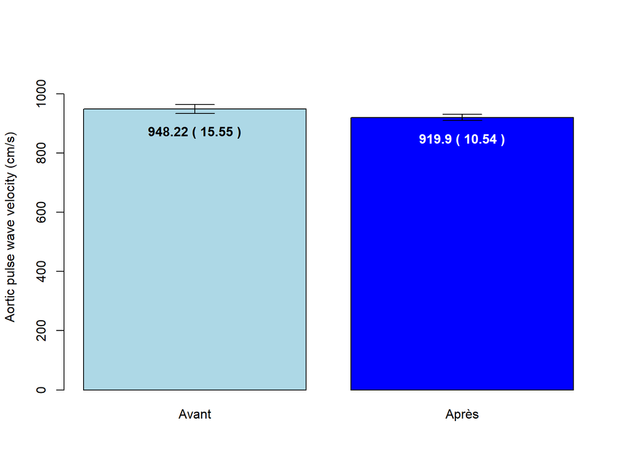

```r
aop_be = sport$aortic.pulse.wave.before
aop_af = sport$aortic.pulse.wave.after

APW_diag = barplot(c(mean(aop_be),mean(aop_af)),names.arg = c("Avant","Après"),
                   ylim=c(0,1100),
                   col= c("lightblue","blue"),
                   ylab = "Aortic pulse wave velocity (cm/s)")

text(APW_diag,y= c(870,845), c(tab1[1,1],tab1[1,2]) , cex=1,font = 2,col = c("black","white"))

arrows(APW_diag,c(mean(aop_be)-SEM(aop_be),mean(aop_af)-SEM(aop_af)),APW_diag,
       c(mean(aop_be)+SEM(aop_be),mean(aop_af)+SEM(aop_af)),code=3,angle=90)
```

### Plasma nitrite

On peut observer une forte augmentation de la **concentration plasmatique en** **nitrite/nitrate** suite à l’étude, avec une augmentation de la moyenne d’environ +20 et +3 pour le SEM.

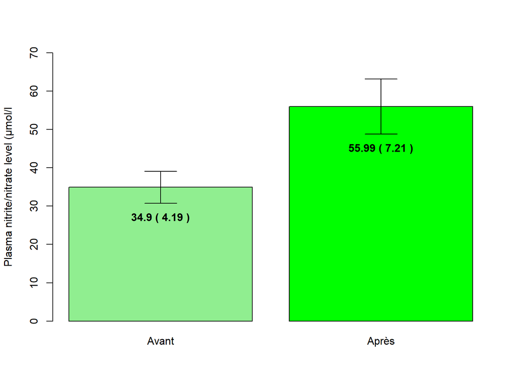

```r
pn_be = sport$plasma.nitrite.before
pn_af = sport$plasma.nitrite.after

PN_diag = barplot(c(mean(pn_be),mean(pn_af)),names.arg = c("Avant","Après"),
                  ylim=c(0,70),col= c("lightgreen","green"),
                  ylab ="Plasma nitrite/nitrate level (μmol/l")

text(PN_diag,y= c(27,45), c(tab1[2,1],tab1[2,2]) , cex=1,font = 2)

arrows(PN_diag,c(mean(pn_be)-SEM(pn_be),mean(pn_af)-SEM(pn_af)),PN_diag,
       c(mean(pn_be)+SEM(pn_be),mean(pn_af)+SEM(pn_af)),code=3,angle=90)
```

### Plasma Endothelin

Une faible augmentation de la concentration plasmatique en **endothéline-1** peut être observée suite à l’étude.

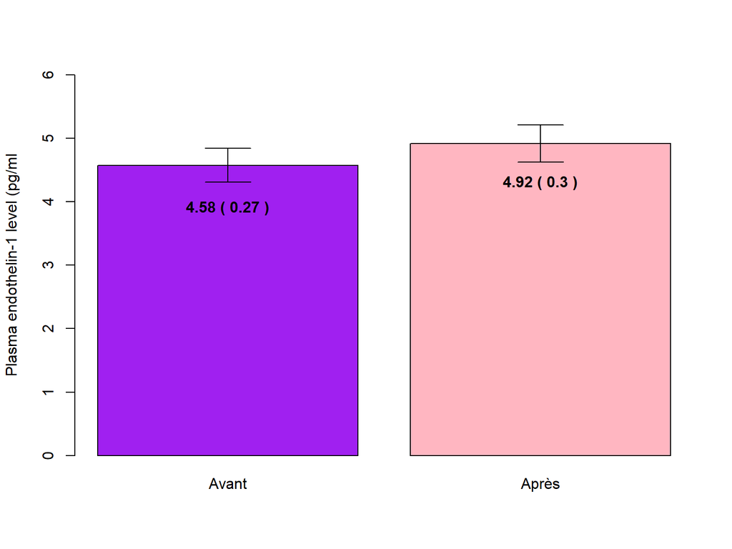

```r
pe_be = sport$plasma.endothelin.before
pe_af = sport$plasma.endothelin.after

ED_diag = barplot(c(mean(pe_be),mean(pe_af)),names.arg = c("Avant","Après"),
                  ylim=c(0,6),col= c("purple","lightpink"),
                  ylab="Plasma endothelin-1 level (pg/ml")

text(ED_diag,y= c(3.9,4.3), c(tab1[3,1],tab1[3,2]) , cex=1,font = 2)

arrows(ED_diag,c(mean(pe_be)-SEM(pe_be),mean(pe_af)-SEM(pe_af)),ED_diag,
       c(mean(pe_be)+SEM(pe_be),mean(pe_af)+SEM(pe_af)),code=3,angle=90)
```

Nous allons maintenant chercher à savoir si nous sommes dans un cadre gaussien.

## Test de normalité

On peut nous pouvons commencer par représenter graphiquement nos données sous forme de boîtes à moustaches et de diagrammes quantiles-quantiles afin montrer une “supposition” de normalité.

Choisissons arbitrairement deux variables : `max.strength.after` et `heart.rate.before`

L’observation dans les boites à moustache de la médiane au centre de la boite (boites symétriques) ainsi que l’absence de points en dehors de la zone bleue dans les diagrammes quantiles-quantiles pousse à confirmer la normalité de nos données.

### Max strength (after)

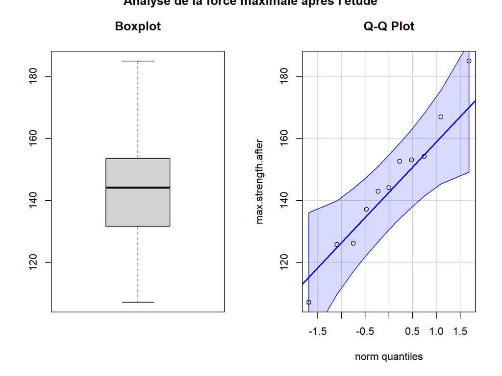

```r
par(mfrow = c(1,2))

boxplot(sport$max.strength.after, main="Boxplot")
with(sport, qqPlot(max.strength.after, dist="norm", id=list(method="y", n=0,labels=rownames(sport)),main="Q-Q Plot"))

title(outer = T,main="Analyse de la force maximale après l'étude")
```

### Heart rate (before)

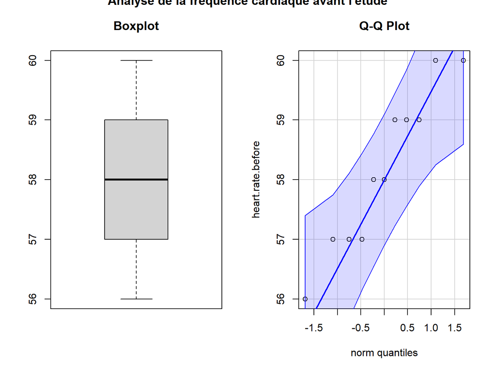

```r
par(mfrow = c(1,2))

boxplot(sport$heart.rate.before,main="Boxplot")
with(sport, qqPlot(heart.rate.before, dist="norm", id=list(method="y", n=0, labels=rownames(sport)),main="Q-Q Plot"))

title(outer = T,main="Analyse de la fréquence cardiaque avant l'étude")
```

Pour ces deux variables, nous avons donc une suspicion de normalité. Afin de s’en assurer, nous allons réaliser des tests de Shapiro-Wilk (*taille échantillon<5000*).

## Test de Shapiro-Wilk

Définissons une fonction `analyse_normalite` qui effectuera un test de Shapiro-Wilk pour chacune des nos variables et retournera dans une table la p-valeur obtenue.

```r
 analyse_normalite <- function(data) {

  shapiro_tests <- lapply(data, shapiro.test)


  p_valeurs <- sapply(shapiro_tests, function(x) {
    if (!is.null(x)) x$p.value else NA
  })


  table_resultats <- as.table(t(p_valeurs))
  rownames(table_resultats) <- "p-valeur"


  formatted_table <- table_resultats %>%
    kable(format = "html",
          digits = 4,
          caption = "Résultats des Tests de Normalité de Shapiro-Wilk",
          align = "c") %>%
    kable_styling(bootstrap_options = c("striped", "hover", "condensed", "responsive"),
                  full_width = FALSE,
                  position = "center") %>%
    row_spec(0, bold = TRUE, background = "#F0F0F0") %>%
    footnote(general = " p > 0.05 suggère une distribution normale",
            general_title = "Note : ",
            footnote_as_chunk = TRUE)

  return(formatted_table)
}
```

### Avant

Obtenons la p-valeur pour nos variables avant l’étude.

```r
sport_avant = sport[,(1:15)]
analyse_normalite(sport_avant)
```

Résultats des Tests de Normalité de Shapiro-Wilk

|  | height | body.weight.before | bmi.before | heart.rate.before | blood.pressure.sys.before | blood.pressure.dia.before | tot.chol.before | hdl.chol.before | ldl.chol.before | serum.insulin.before | plasma.glucose.before | max.strength.before | aortic.pulse.wave.before | plasma.nitrite.before | plasma.endothelin.before |
| --- | --- | --- | --- | --- | --- | --- | --- | --- | --- | --- | --- | --- | --- | --- | --- |
| p-valeur | 0.107 | 0.1425 | 0.2311 | 0.3795 | 0.929 | 0.2775 | 0.4068 | 0.5536 | 0.5135 | 0.591 | 0.1259 | 0.6662 | 0.0061 | 0.2306 | 0.0466 |

Note : p > 0.05 suggère une distribution normale

### Après

Obtenons la p-valeur pour nos variables après l’étude.

```r
sport_après = sport[,(16:29)]
analyse_normalite(sport_après)
```

Résultats des Tests de Normalité de Shapiro-Wilk

|  | body.weight.after | bmi.after | heart.rate.after | blood.pressure.sys.after | blood.pressure.dia.after | tot.chol.after | hdl.chol.after | ldl.chol.after | serum.insulin.after | plasma.glucose.after | max.strength.after | aortic.pulse.wave.after | plasma.nitrite.after | plasma.endothelin.after |
| --- | --- | --- | --- | --- | --- | --- | --- | --- | --- | --- | --- | --- | --- | --- |
| p-valeur | 0.7447 | 0.6025 | 0.007 | 0.4292 | 0.8928 | 0.9452 | 0.1795 | 0.313 | 0.8479 | 0.3879 | 0.9723 | 0.1264 | 0.7451 | 0.0149 |

Note : p > 0.05 suggère une distribution normale

## Observation

Nous pouvons observer que la majorité des variables, sans distinction avant/après, retournaient une p-valeur supérieure au seuil de 0.05 au test de Shapiro-Wilk. Cependant certaines variables ont retourné une p-valeur inférieure, telle que `plasma.endothelin.before`.

```r
shapiro.test(sport$plasma.endothelin.before)
```

```
##
##  Shapiro-Wilk normality test
##
## data:  sport$plasma.endothelin.before
## W = 0.85296, p-value = 0.04665
```

Ainsi on rejetterait la normalité pour cette variable. Traçons un diagramme quantiles-quantiles pour regarder s’ il n’y a pas de valeurs extrêmes.

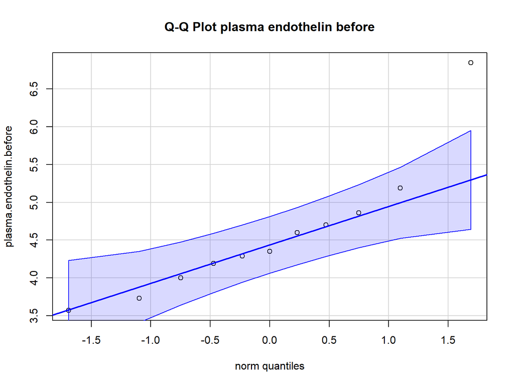

```r
with(sport, qqPlot(plasma.endothelin.before, dist="norm", id=list(method="y", n=0, labels=rownames(sport)),main="Q-Q Plot plasma endothelin before"))
```

Nous pouvons donc voir qu’il y a une valeur extrême : 6.85. Essayons de faire le test sans cette valeur.

```r
shapiro.test(sport$plasma.endothelin.before[sport$plasma.endothelin.before != 6.85])
```

```
##
##  Shapiro-Wilk normality test
##
## data:  sport$plasma.endothelin.before[sport$plasma.endothelin.before != 6.85]
## W = 0.98549, p-value = 0.9878
```

## Test de Student apparié

Le test de student est un test sur les moyennes (H0 : moyenne_avant = moyenne_après). Nous considérerons le seuil *alpha* égal à 0.05.

```r
variables <- c("body.weight.before","bmi.before","heart.rate.before",
               "blood.pressure.sys.before", "blood.pressure.dia.before",
               "tot.chol.before","hdl.chol.before" ,"ldl.chol.before",
               "serum.insulin.before","plasma.glucose.before",
               "max.strength.before","aortic.pulse.wave.before",
               "plasma.nitrite.before","plasma.endothelin.before" )


run_student_tests <- function(data, vars) {
  results <- data.frame()
  for (var in vars) {
    before <- data[[var]]
    after <- data[[gsub("\\.before", "\\.after", var)]]
    t_test <- t.test(before, after, paired = TRUE)
    results <- rbind(results, data.frame(
      variable = gsub("\\.before", "", var),
      p_value = round(t_test$p.value,4)
    ))
  }

  return(results)
}

run_student_tests(sport, variables)
```

```
##              variable p_value
## 1         body.weight  0.1746
## 2                 bmi  0.1720
## 3          heart.rate  0.0491
## 4  blood.pressure.sys  0.6131
## 5  blood.pressure.dia  0.4134
## 6            tot.chol  0.2193
## 7            hdl.chol  0.5181
## 8            ldl.chol  0.1049
## 9       serum.insulin  0.0024
## 10     plasma.glucose  0.0203
## 11       max.strength  0.0037
## 12  aortic.pulse.wave  0.1031
## 13     plasma.nitrite  0.0321
## 14  plasma.endothelin  0.3098
```

Ainsi nous pouvons conclure qu’au risque de 5%, cinq variables ont montré une différence significative entre les moyennes avant et après. Ces variables sont :

- Force musculaire maximale *(max.strength)*
- Concentration plasmatique en nitrite/nitrate *(plasma.nitrite)*
- Fréquence cardiaque (*heart.rate)*
- Concentration plasmatique en glucose *(plasma.glucose)*
- Concentration en insuline sérine *(serum.insulin)*

# Conclusion

De part l’observation des résultats, nous pouvons en conclure qu’il y a eu une :

Diminution significative :

- Concentration en insuline sérine *(serum.insulin)*